# ISLR 3: Linear regression

Jorge Rotter

## Question 8

This question involves the use of simple linear regression on the `Auto` data set.

**(a)** Use the `lm` function to perform a simple linear regression with `mpg` as the response and `horsepower` as the predictor. Use the `summary` function to print the results. Comment on the output.

```r
q8 <- lm(mpg ~ horsepower, data = Auto)
summary(q8)
```

```
Call:
lm(formula = mpg ~ horsepower, data = Auto)

Residuals:
     Min       1Q   Median       3Q      Max
-13.5710  -3.2592  -0.3435   2.7630  16.9240

Coefficients:
             Estimate Std. Error t value Pr(>|t|)
(Intercept) 39.935861   0.717499   55.66   <2e-16 ***
horsepower  -0.157845   0.006446  -24.49   <2e-16 ***
---
Signif. codes:  0 ‘***’ 0.001 ‘**’ 0.01 ‘*’ 0.05 ‘.’ 0.1 ‘ ’ 1

Residual standard error: 4.906 on 390 degrees of freedom
Multiple R-squared:  0.6059,    Adjusted R-squared:  0.6049
F-statistic: 599.7 on 1 and 390 DF,  p-value: < 2.2e-16
```

Hay una correlación negativa mediana entre ambas. Por el bajo valor p, concluimos que la relación es estadísticamente significativa.

**(b)** Plot the response and the predictor

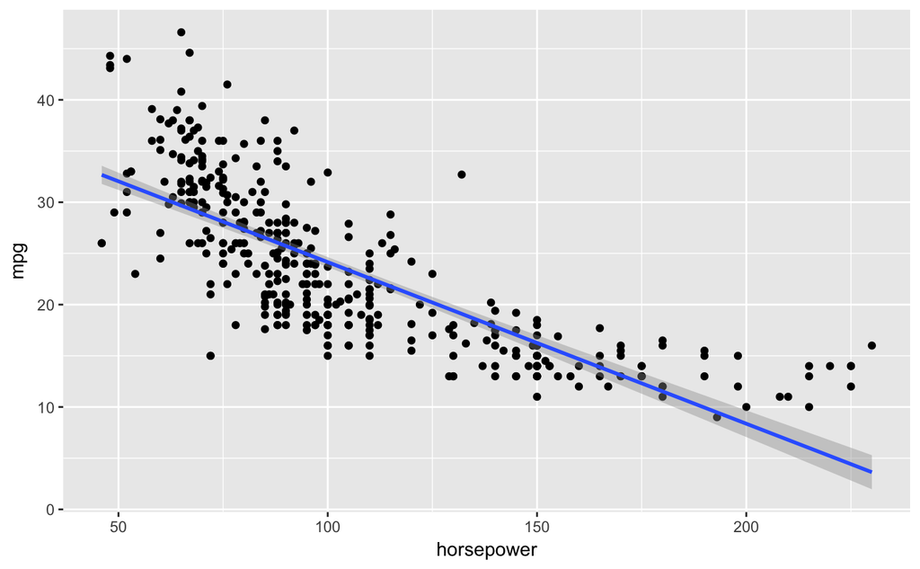

```r
p <- ggplot(Auto, aes(x = horsepower, y = mpg)) +
  geom_point() +
  geom_smooth(method = 'lm')
p
```

**(c)**

Use the `plot` function to produce diagnostic plots of the least squares regression fit. Comment on any problems you see with the fit.

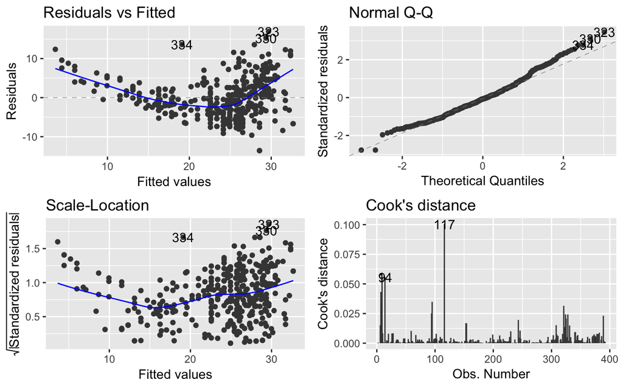

```r
autoplot(q8, which = 1:4)
```

De la primera gráfica podemos ver evidencias de no-linealidad, pues los residuos siguen un patrón de parábola. La gráfica cuantil-cuantil vemos que los datos en su mayoría sí son normales. De la tercera gráfica suponemos heterocedasticidad (que revisaremos a continuación con la prueba de Breusch-Pagan), pues los datos están más dispersos antes del quince y menos dispersos después. De la última vemos que la observación 117 es un punto de alto apalancamiento.

```r
ncvTest(q8)
```

```
Non-constant Variance Score Test
Variance formula: ~ fitted.values
Chisquare = 10.06111    Df = 1     p = 0.001514323
```

De esta prueba vemos que el pequeño valor p efectivamente nos lleva a rechazar la hipótesis de homocedasticidad. Ahora bien, graficando de nuevo pero haciendo énfasis en las observaciones 117 y 94

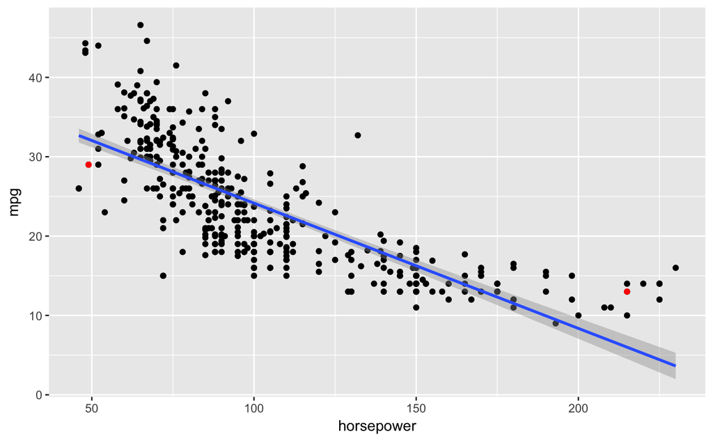

```r
puntos_raros <- Auto[c(94, 117),]
p + geom_point(data = puntos_raros, aes(x = horsepower, y = mpg), colour = 'red')
```

Finalmente, eliminando ambas observaciones del modelo para ver qué obtenemos.

```r
sin_raros <- Auto[-c(94, 117), ]
q8_sin_raros <- lm(mpg ~ horsepower, data = sin_raros)
summary(q8_sin_raros)
```

```
Call:
lm(formula = mpg ~ horsepower, data = sin_raros)

Residuals:
    Min      1Q  Median      3Q     Max
-13.616  -3.221  -0.290   2.707  16.867

Coefficients:
             Estimate Std. Error t value Pr(>|t|)
(Intercept) 40.102207   0.724875   55.32   <2e-16 ***
horsepower  -0.159533   0.006528  -24.44   <2e-16 ***
---
Signif. codes:  0 ‘***’ 0.001 ‘**’ 0.01 ‘*’ 0.05 ‘.’ 0.1 ‘ ’ 1

Residual standard error: 4.902 on 388 degrees of freedom
Multiple R-squared:  0.6062,    Adjusted R-squared:  0.6052
F-statistic: 597.2 on 1 and 388 DF,  p-value: < 2.2e-16
```

No mejoró.

## Question 9

This question involves the use of multiple linear regression on the `Auto` data set.

**(a)** Produce a scatterplot matrix which includes all of the variables in the data set.

[output not shown]

[output cut: 9 more lines]

[output not shown]

**(b)** Compute the matrix of correlations between the variables using the function cor(). You will need to exclude the name variable, which is qualitative.

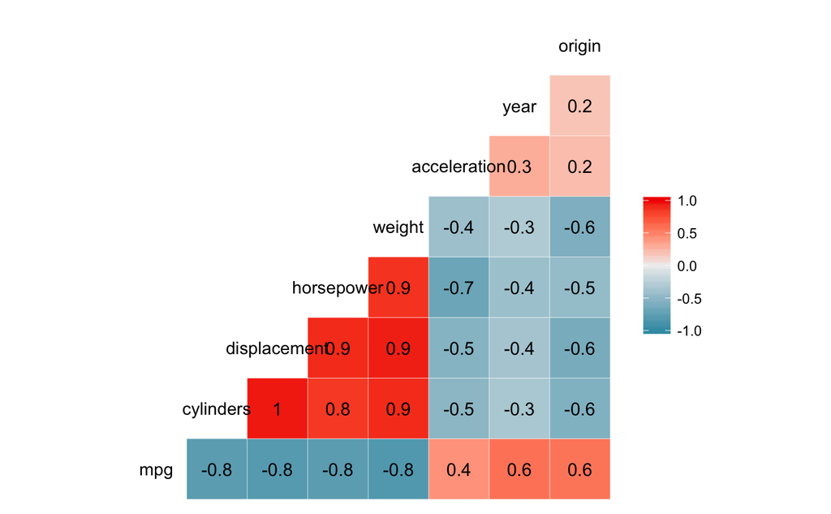

```r
Auto %>%
  select(-name) %>%
  ggcorr(label = TRUE)
```

**(c)** Use the `lm()` function to perform a multiple linear regression with `mpg` as the response and all other variables except `name` as the predictors. Use the `summary() function to print the results. Comment on the output. For instance:

```r
model_q9c <- lm(mpg ~ . - name, data = Auto)
summary(model_q9c)
```

```
Call:
lm(formula = mpg ~ . - name, data = Auto)

Residuals:
    Min      1Q  Median      3Q     Max
-9.5903 -2.1565 -0.1169  1.8690 13.0604

Coefficients:
               Estimate Std. Error t value Pr(>|t|)
(Intercept)  -17.218435   4.644294  -3.707  0.00024 ***
cylinders     -0.493376   0.323282  -1.526  0.12780
displacement   0.019896   0.007515   2.647  0.00844 **
horsepower    -0.016951   0.013787  -1.230  0.21963
weight        -0.006474   0.000652  -9.929  < 2e-16 ***
acceleration   0.080576   0.098845   0.815  0.41548
year           0.750773   0.050973  14.729  < 2e-16 ***
origin         1.426141   0.278136   5.127 4.67e-07 ***
---
Signif. codes:  0 ‘***’ 0.001 ‘**’ 0.01 ‘*’ 0.05 ‘.’ 0.1 ‘ ’ 1

Residual standard error: 3.328 on 384 degrees of freedom
Multiple R-squared:  0.8215,    Adjusted R-squared:  0.8182
F-statistic: 252.4 on 7 and 384 DF,  p-value: < 2.2e-16
```

Las únicas variables estadísticamente significativas son `weight`, `year` y `origin`, posiblemente también `displacement`. El coeficiente de `year` sugiere que conforme pasan los años, se construyen autos más rendidores.

**(d)** Use the `plot()` function to produce diagnostic plots of the linear regression fit. Comment on any problems you see with the fit. Do the residual plots suggest any unusually large outliers? Does the leverage plot identify any observations with unusually high leverage?

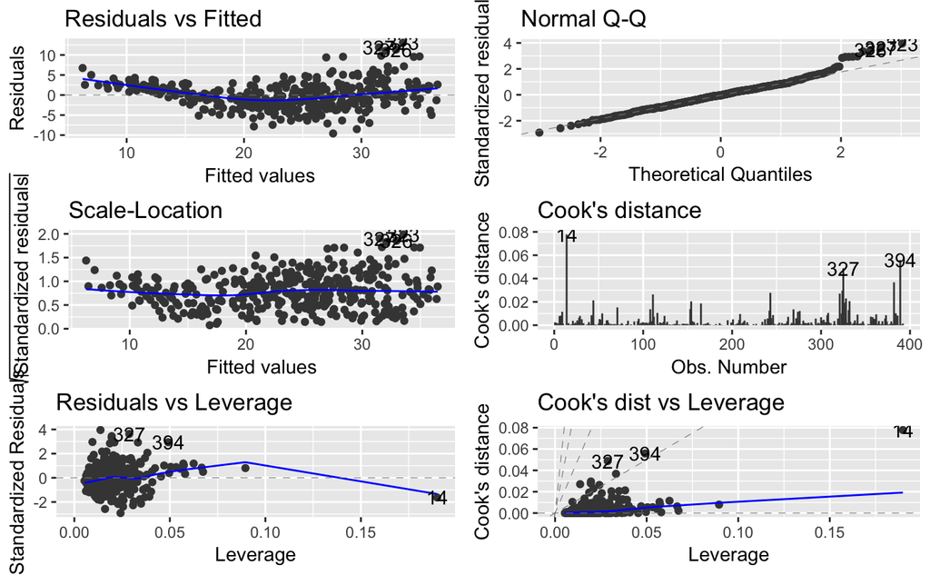

De la priemra gráfica podemos concluir que hay una relación no-lineal que el modelo no está capturando. De la segunda, que la distribución de los residuos no es normal; de hecho tiene una joroba pequeñita a la derecha. De la tercera parece que la varianza de los residuos no es constante; de hecho es más pequeña antes del quince. Por último, la observación 14 tiene mucho apalancamiento pero no tan alto residuo. Graficando las extra de `autoplot()` vemos que las observaciones 327 y 394 tienen Cook’s Distance relativamente alta pero no preocupantemente alta.

**(e)** Use the `*` and `:` symbols to fit linear regression models with interaction effects. Do any interactions appear to be statistically significant?

```r
model_q9e <- lm(mpg ~ weight + year + displacement*weight + acceleration*horsepower, data = Auto)
summary(model_q9e)
```

```
Call:
lm(formula = mpg ~ weight + year + displacement * weight + acceleration *
    horsepower, data = Auto)

Residuals:
    Min      1Q  Median      3Q     Max
-9.5011 -1.7434 -0.0067  1.5542 12.4216

Coefficients:
                          Estimate Std. Error t value Pr(>|t|)
(Intercept)             -1.355e+01  4.818e+00  -2.813  0.00517 **
weight                  -8.731e-03  8.551e-04 -10.211  < 2e-16 ***
year                     7.842e-01  4.476e-02  17.521  < 2e-16 ***
displacement            -7.192e-02  8.158e-03  -8.815  < 2e-16 ***
acceleration             5.868e-01  1.532e-01   3.830  0.00015 ***
horsepower               5.563e-02  2.367e-02   2.350  0.01928 *
weight:displacement      2.021e-05  2.265e-06   8.925  < 2e-16 ***
acceleration:horsepower -7.038e-03  1.705e-03  -4.128  4.5e-05 ***
---
Signif. codes:  0 ‘***’ 0.001 ‘**’ 0.01 ‘*’ 0.05 ‘.’ 0.1 ‘ ’ 1

Residual standard error: 2.916 on 384 degrees of freedom
Multiple R-squared:  0.8629,    Adjusted R-squared:  0.8604
F-statistic: 345.4 on 7 and 384 DF,  p-value: < 2.2e-16
```

**(f)**Try a few different transformations of the variables, such as `log(X)`, `√X` Comment on your findings.

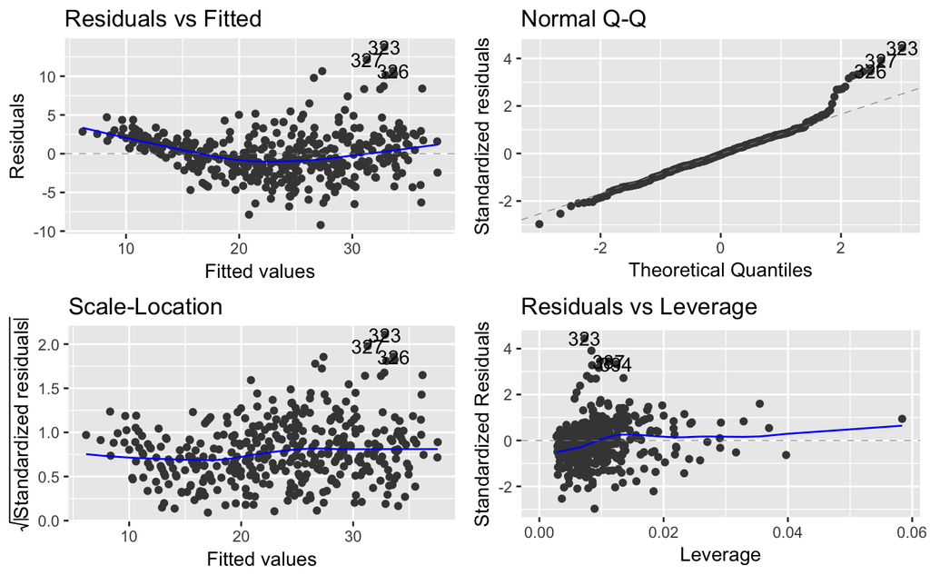

Pues no logro encontrar lo no-lineal, pero es claro que existe.

## Question 10

This question should be answered using the `Carseats` data set.

**(a)** Fit a multiple regression model to predict `Sales` using `Price`,`Urban`, and `US`.

```r
model_10a <- lm(Sales ~ Price + Urban + US, data = Carseats)
```

**(b)** Provide an interpretation of each coefficient in the model. Becareful—some of the variables in the model are qualitative!

```r
summary(model_10a)
```

```
Call:
lm(formula = Sales ~ Price + Urban + US, data = Carseats)

Residuals:
    Min      1Q  Median      3Q     Max
-6.9206 -1.6220 -0.0564  1.5786  7.0581

Coefficients:
             Estimate Std. Error t value Pr(>|t|)
(Intercept) 13.043469   0.651012  20.036  < 2e-16 ***
Price       -0.054459   0.005242 -10.389  < 2e-16 ***
UrbanYes    -0.021916   0.271650  -0.081    0.936
USYes        1.200573   0.259042   4.635 4.86e-06 ***
---
Signif. codes:  0 ‘***’ 0.001 ‘**’ 0.01 ‘*’ 0.05 ‘.’ 0.1 ‘ ’ 1

Residual standard error: 2.472 on 396 degrees of freedom
Multiple R-squared:  0.2393,    Adjusted R-squared:  0.2335
F-statistic: 41.52 on 3 and 396 DF,  p-value: < 2.2e-16
```

**(d)** For which of the predictors can you reject the null hypothesis H0 : βj = 0?

Podemos rechazar la hipótesis nula en `Price` y `US`.

**(e)** On the basis of your response to the previous question, fit a smaller model that only uses the predictors for which there is evidence of association with the outcome.

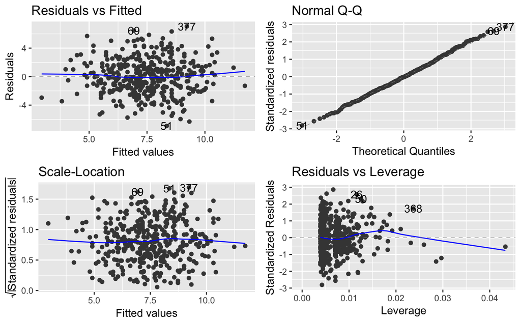

El modelo efectivamente captura las relaciones; pues los errores sí siguen una normal con media 0 y varianza constante. Además, parece no haber puntos de alto apalancamiento.

**(g)** Using the model from (e), obtain 95% confidence intervals for the coefficient(s). confi

```r
confint(model_10e, level = 0.95)
```

```
                  2.5 %      97.5 %
(Intercept) 11.79032020 14.27126531
Price       -0.06475984 -0.04419543
USYes        0.69151957  1.70776632
```

**(h)** Is there evidence of outliers or high leverage observations in the model from (e)?

No realmente. La gráfica de residuos estandarizados contra apalancamiento muestra que casi todos tienen bajo apalancamiento (salvo un punto con alto apalancamiento relativo pero igual tiene pequeña distancia de Cook.)

## Question 11

In this problem we will investigate the t-statistic for the null hypothesis H0 : β = 0 in simple linear regression without an intercept. To begin, we generate a predictor x and a response y as follows.

**(a)**Perform a simple linear regression of y onto x, without an in- tercept. Report the coefficient estimate β, the standard error of this coefficient estimate, and the t-statistic and p-value associated with the null hypothesis H0 : β = 0. Comment on these results.

```r
  model_11a <- lm(y ~ x + 0)
  summary(model_11a)
```

```
Call:
lm(formula = y ~ x + 0)

Residuals:
    Min      1Q  Median      3Q     Max
-1.9154 -0.6472 -0.1771  0.5056  2.3109

Coefficients:
  Estimate Std. Error t value Pr(>|t|)
x   1.9939     0.1065   18.73   <2e-16 ***
---
Signif. codes:  0 ‘***’ 0.001 ‘**’ 0.01 ‘*’ 0.05 ‘.’ 0.1 ‘ ’ 1

Residual standard error: 0.9586 on 99 degrees of freedom
Multiple R-squared:  0.7798,    Adjusted R-squared:  0.7776
F-statistic: 350.7 on 1 and 99 DF,  p-value: < 2.2e-16
```

El valor p es tan pequeño que podemos rechazar la hipótesis nula certeramente.

**(b)** Now perform a simple linear regression of x onto y without an intercept, and report the coefficient estimate, its standard error, and the corresponding t-statistic and p-values associated with the null hypothesis H0 : β = 0. Comment on these results.

```r
summary(model_11b)
```

```
Call:
lm(formula = x ~ y + 0)

Residuals:
    Min      1Q  Median      3Q     Max
-0.8699 -0.2368  0.1030  0.2858  0.8938

Coefficients:
  Estimate Std. Error t value Pr(>|t|)
y  0.39111    0.02089   18.73   <2e-16 ***
---
Signif. codes:  0 ‘***’ 0.001 ‘**’ 0.01 ‘*’ 0.05 ‘.’ 0.1 ‘ ’ 1

Residual standard error: 0.4246 on 99 degrees of freedom
Multiple R-squared:  0.7798,    Adjusted R-squared:  0.7776
F-statistic: 350.7 on 1 and 99 DF,  p-value: < 2.2e-16
```

## Question 12

**(a)** Recall that the coefficient estimate $\hat{\beta}$ for the linear regression of Y onto X without an intercept is given by (3.38). Under what circumstance is the coefficient estimate for the regression of X onto Y the same as the coefficient estimate for the regression of Y onto X?

Ambos coeficientes son iguales cuando la suma de cuadrados de los $x_i$ son iguales a los de los $y_i$.

**(b)** Generate an example in `R` with $n$ = 100 observations in which the coefficient estimate for the regression of $X$ onto $Y$ is *different* from the coefficient estimate for the regression of $Y$ onto $X$.

```r
x <- rnorm(100)
y <- rnorm(100)
coef(lm(y ~ x + 0))
```

```
        x
-0.028014
```

```r
coef(lm(x ~ y + 0))
```

```
          y
-0.02835724
```

**(c)** Generate an example in R with $n$ = 100 observations in which the coefficient estimate for the regression of $X$ onto $Y$ is the same as the coefficient estimate for the regression of $Y$ onto $X$.

```r
x <- rnorm(100)
y <- sample(x)
coef(lm(y ~ x + 0))
```

```
          x
-0.06552108
```

```r
coef(lm(x ~ y + 0))
```

```
          y
-0.06552108
```

# Question 13

In this exercise you will create some simulated data and will fit simple linear regression models to it. Make sure to use `set.seed(1)` prior to starting part (a) to ensure consistent results.

**(a)** Using the `rnorm()` function, create a vector, `x`, containing 100 observations drawn from a $N(0, 1)$ distribution. This represents a feature, $X$.

**(b)** Using the `rnorm()` function, create a vector, `eps`, containing 100 observations drawn from a $N(0,0.25)$ distribution i.e. a normal distribution with mean zero and variance 0.25.

**(c)** Using `x` and `eps`, generate a vector `y` according to the model
$$Y = -1 + 0.5X + \epsilon$$

```r
y <- -1 + 0.5*x + eps
```

[output not shown]

***(d)** Create a scatterplot displaying the relationship between `x` and `y`. Comment on what you observe.

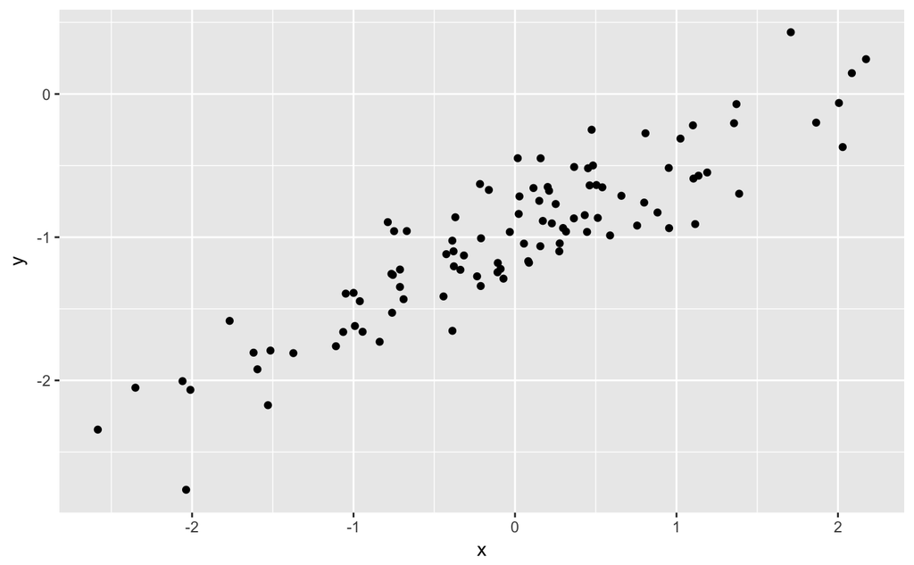

```r
data.frame(x = x, y = y) %>%
  ggplot(aes(x = x, y = y)) +
    geom_point()
```

Aunque el modelo nos dice que la relación real entre ambas variables es lineal, el ruido introducido por el término $\epsilon$ hace que se vea como algo extraño no-recta. También tiene que ver que hay puntos encimados por la naturaleza estocástica de `x`.

**(e)** Fit a least squares linear model to predict `y` using `x`. Comment on the model obtained. How do $\hat{\beta_0}$ and $\hat{\beta_1}$ compare to $\beta_0$ and $\beta_1$ ?

```r
model_13e <- lm(y ~ x)
summary(model_13e)
```

```
Call:
lm(formula = y ~ x)

Residuals:
     Min       1Q   Median       3Q      Max
-0.67072 -0.15508  0.03027  0.14433  0.67861

Coefficients:
            Estimate Std. Error t value Pr(>|t|)
(Intercept) -0.98272    0.02757  -35.65   <2e-16 ***
x            0.48368    0.02593   18.65   <2e-16 ***
---
Signif. codes:  0 ‘***’ 0.001 ‘**’ 0.01 ‘*’ 0.05 ‘.’ 0.1 ‘ ’ 1

Residual standard error: 0.275 on 98 degrees of freedom
Multiple R-squared:  0.7802,    Adjusted R-squared:  0.778
F-statistic: 347.9 on 1 and 98 DF,  p-value: < 2.2e-16
```

Las aproximaciones son cercanas.

**(f)** Display the least squares line on the scatterplot obtained in (d). Draw the population regression line on the plot, in a different color. Create an appropiate legend.

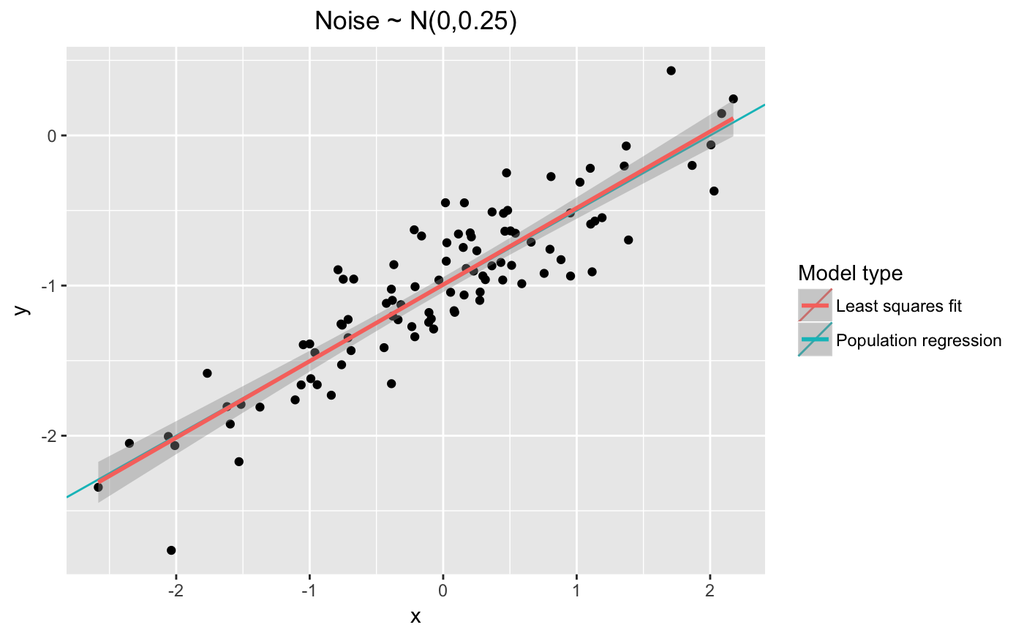

```r
data.frame(x = x, y = y ) %>%
  ggplot(aes(x = x, y = y)) +
    geom_point() +
    geom_abline(aes(colour = "Population regression", slope = 0.5, intercept = -1)) +
    stat_smooth(aes(colour = 'Least squares fit'), method = 'lm') +
    scale_color_discrete(name = 'Model type') +
    ggtitle("Noise ~ N(0,0.25)") +
    theme(plot.title = element_text(hjust = 0.5))
```

**(g)** Now fit a polynomial regression model that predicts `y` using `x` and `x^2`. Is there evidence that the quadratic term improves the model fit? Explain your answer.

```r
model_13g <- lm(y ~ x + I(x^2))
summary(model_13g)
```

```
Call:
lm(formula = y ~ x + I(x^2))

Residuals:
    Min      1Q  Median      3Q     Max
-0.6710 -0.1554  0.0299  0.1439  0.6788

Coefficients:
              Estimate Std. Error t value Pr(>|t|)
(Intercept) -0.9822659  0.0338769 -28.995   <2e-16 ***
x            0.4836929  0.0260737  18.551   <2e-16 ***
I(x^2)      -0.0004058  0.0172911  -0.023    0.981
---
Signif. codes:  0 ‘***’ 0.001 ‘**’ 0.01 ‘*’ 0.05 ‘.’ 0.1 ‘ ’ 1

Residual standard error: 0.2764 on 97 degrees of freedom
Multiple R-squared:  0.7802,    Adjusted R-squared:  0.7757
F-statistic: 172.2 on 2 and 97 DF,  p-value: < 2.2e-16
```

No hay evidencia alguna de que el modelo mejore. El valor p del coeficiente de $X^2$ no permite descartar la hipótesis nula y $R^2$ no mejora.

**(h)** Repeat (a)–(f) after modifying the data generation process in such a way that there is *less* noise in the data. The model (3.39) should remain the same. Describe your results.

```r
x <- rnorm(100)
eps <- rnorm(n = 100, sd = 0.10)
y <- -1 + 0.5*x + eps
model_13h <- lm(y ~ x)
summary(model_13h)
```

```
Call:
lm(formula = y ~ x)

Residuals:
     Min       1Q   Median       3Q      Max
-0.25563 -0.06210 -0.01286  0.07413  0.21075

Coefficients:
            Estimate Std. Error t value Pr(>|t|)
(Intercept) -1.01727    0.01035  -98.25   <2e-16 ***
x            0.48668    0.00963   50.54   <2e-16 ***
---
Signif. codes:  0 ‘***’ 0.001 ‘**’ 0.01 ‘*’ 0.05 ‘.’ 0.1 ‘ ’ 1

Residual standard error: 0.103 on 98 degrees of freedom
Multiple R-squared:  0.963, Adjusted R-squared:  0.9627
F-statistic:  2554 on 1 and 98 DF,  p-value: < 2.2e-16
```

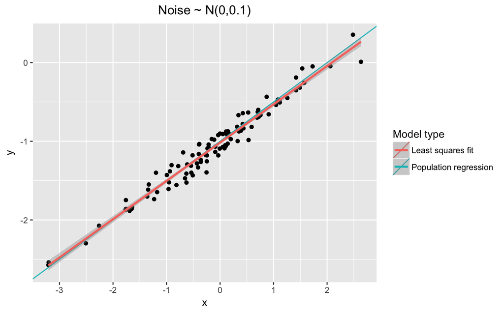

```r
data.frame(x = x, y = y ) %>%
  ggplot(aes(x = x, y = y)) +
    geom_point() +
    geom_abline(aes(colour = "Population regression", slope = 0.5, intercept = -1)) +
    stat_smooth(aes(colour = 'Least squares fit'), method = 'lm') +
    scale_color_discrete(name = 'Model type') +
    ggtitle("Noise ~ N(0,0.1)") +
    theme(plot.title = element_text(hjust = 0.5))
```

La línea de mínimos cuadrados está mucho más cercana al modelo real.

**(i)** Repeat (a)–(f) after modifying the data generation process in such a way that there is *more* noise in the data. The model (3.39) should remain the same. Describe your results.

```r
x <- rnorm(100)
eps <- rnorm(n = 100, sd = 0.5)
y <- -1 + 0.5*x + eps
model_13i <- lm(y ~ x)
summary(model_13i)
```

```
Call:
lm(formula = y ~ x)

Residuals:
     Min       1Q   Median       3Q      Max
-1.13466 -0.29908 -0.00864  0.31038  1.23260

Coefficients:
            Estimate Std. Error t value Pr(>|t|)
(Intercept) -1.01853    0.04265  -23.88   <2e-16 ***
x            0.54032    0.03978   13.58   <2e-16 ***
---
Signif. codes:  0 ‘***’ 0.001 ‘**’ 0.01 ‘*’ 0.05 ‘.’ 0.1 ‘ ’ 1

Residual standard error: 0.4265 on 98 degrees of freedom
Multiple R-squared:  0.6531,    Adjusted R-squared:  0.6495
F-statistic: 184.5 on 1 and 98 DF,  p-value: < 2.2e-16
```

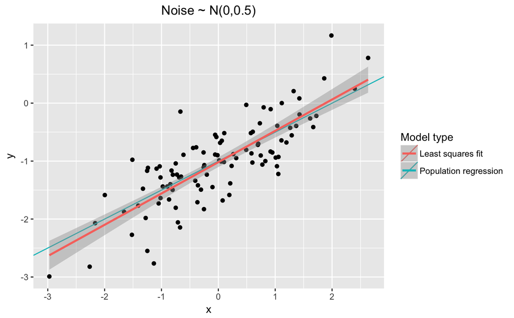

```r
data.frame(x = x, y = y ) %>%
  ggplot(aes(x = x, y = y)) +
    geom_point() +
    geom_abline(aes(colour = "Population regression", slope = 0.5, intercept = -1)) +
    stat_smooth(aes(colour = 'Least squares fit'), method = 'lm') +
    scale_color_discrete(name = 'Model type') +
    ggtitle("Noise ~ N(0,0.5)") +
    theme(plot.title = element_text(hjust = 0.5))
```

**(j)** What are the confidence intervals for $\beta_0$ and $\beta_1$ based on the original data set, the noisier data set, and the less noisy data set? Comment on your results.

```r
confint(model_13e)
```

[output not shown]

```r
confint(model_13h)
```

```
                 2.5 %     97.5 %
(Intercept) -1.0378188 -0.9967252
x            0.4675653  0.5057847
```

```r
confint(model_13i)
```

```
                 2.5 %     97.5 %
(Intercept) -1.1031741 -0.9338923
x            0.4613715  0.6192605
```

## Question 14

This problem focuses on the *collinearity* problem.

**(a)** Perform the following commands:

**(b)** What is the correlation between `x1` and `x2`? Create a scatterplot displaying the relationship between the variables.

```r
cor(x1, x2)
```

```
[1] 0.8351212
```

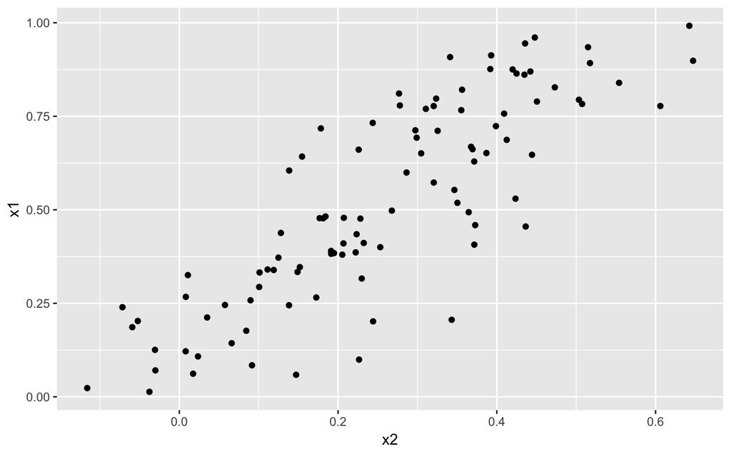

```r
df <- data.frame(x1 = x1, x2 = x2, y = y)
ggplot(df, aes(x = x2, y = x1)) +
  geom_point()
```

La correlación entre `x1` y `x2` es 0.835.

**(c)** Using this data, fit a least squares regression to predict `y` using `x1` and `x2`. Describe the results obtained. What are $\hat{\beta_0}$, $\hat{\beta_1}$, and $\hat{\beta_2}$? How do these relate to the true $\beta_0$, $\beta_1$, and $\beta_2$? Can you reject the null hypothesis $H_0 : \beta_1 = 0$? How about the null hypothesis $H_0 : \beta_2 = 0$

```r
model_14c <- lm(y ~ x1 + x2)
summary(model_14c)
```

```
Call:
lm(formula = y ~ x1 + x2)

Residuals:
    Min      1Q  Median      3Q     Max
-2.8311 -0.7273 -0.0537  0.6338  2.3359

Coefficients:
            Estimate Std. Error t value Pr(>|t|)
(Intercept)   2.1305     0.2319   9.188 7.61e-15 ***
x1            1.4396     0.7212   1.996   0.0487 *
x2            1.0097     1.1337   0.891   0.3754
---
Signif. codes:  0 ‘***’ 0.001 ‘**’ 0.01 ‘*’ 0.05 ‘.’ 0.1 ‘ ’ 1

Residual standard error: 1.056 on 97 degrees of freedom
Multiple R-squared:  0.2088,    Adjusted R-squared:  0.1925
F-statistic:  12.8 on 2 and 97 DF,  p-value: 1.164e-05
```

**(d)** Now fit a least squares regression to predict `y` using only `x1`. Comment on your results. Can you reject the null hypothesis $H_0 : \beta_1 = 0$?

```r
model_13d <- lm(y ~ x1)
summary(model_13d)
```

```
Call:
lm(formula = y ~ x1)

Residuals:
     Min       1Q   Median       3Q      Max
-2.89495 -0.66874 -0.07785  0.59221  2.45560

Coefficients:
            Estimate Std. Error t value Pr(>|t|)
(Intercept)   2.1124     0.2307   9.155 8.27e-15 ***
x1            1.9759     0.3963   4.986 2.66e-06 ***
---
Signif. codes:  0 ‘***’ 0.001 ‘**’ 0.01 ‘*’ 0.05 ‘.’ 0.1 ‘ ’ 1

Residual standard error: 1.055 on 98 degrees of freedom
Multiple R-squared:  0.2024,    Adjusted R-squared:  0.1942
F-statistic: 24.86 on 1 and 98 DF,  p-value: 2.661e-06
```

En este caso, el coeficiente $\beta_1$ fue aproximado mucho mejor, con una diferencia de solo 0.0241. Además, aquí definitivamente puede rechazarse la hipótesis nula.

**(e)** Now fit a least squares regression to predict `y` using only `x2`. Comment on your results. Can you reject the null hypothesis $H_0 : \beta_2 = 0$?

```r
model_13e <- lm(y ~ x2)
summary(model_13e)
```

```
Call:
lm(formula = y ~ x2)

Residuals:
     Min       1Q   Median       3Q      Max
-2.62687 -0.75156 -0.03598  0.72383  2.44890

Coefficients:
            Estimate Std. Error t value Pr(>|t|)
(Intercept)   2.3899     0.1949   12.26  < 2e-16 ***
x2            2.8996     0.6330    4.58 1.37e-05 ***
---
Signif. codes:  0 ‘***’ 0.001 ‘**’ 0.01 ‘*’ 0.05 ‘.’ 0.1 ‘ ’ 1

Residual standard error: 1.072 on 98 degrees of freedom
Multiple R-squared:  0.1763,    Adjusted R-squared:  0.1679
F-statistic: 20.98 on 1 and 98 DF,  p-value: 1.366e-05
```

La aproximación de $\beta_2$ fue *muy* mala; $\hat{\beta_2}$ es casi diez veces más grande. Sin emabrgo, puede rechazarse la hipótesis nula.

**(f)** Do the results obtained in (c)–(e) contradict each other? Explain your answer.

Los resultados no se contradicen. Observemos primero que como `x1` y `x2` están fuertemente correlacionados, incluir solo a `x2` en el modelo da una aproximación del coeficiente $\beta_2$ mucho más alta. Esto se debe a que la correlación etnre ambas variables hace que cuando `x2` crece, también lo hace `x1`, y por tanto `y`. Sin embargo, el modelo con solo `x2` no tiene manera de atribuirle al cambio en `x1` el crecimiento en `y` y por eso aumenta la estimación de $\beta_2$.

**Modelo 2:** Cuando se incluye solo `x1`, el error estándar de la pendiente es 0.39, con estadística t de 4.98

**Modelo 3:** El error estandar es 0.63, con estadística t de 4.58

**(g)** Now suppose we obtain one additional observation, which was unfortunately mismeasured.

```r
x1 <- c(x1, 0.1)
x2 <- c(x2, 0.8)
y <- c(y, 6)
```

Re-fit the linear models from (c) to (e) using this new data. What effect does this new observation have on the each of the models? In each model, is this observation an outlier? A high-leverage point? Both? Explain your answers.

```r
model_14gi <- lm(y ~ x1 + x2)
summary(model_14gi)
```

```
Call:
lm(formula = y ~ x1 + x2)

Residuals:
     Min       1Q   Median       3Q      Max
-2.73348 -0.69318 -0.05263  0.66385  2.30619

Coefficients:
            Estimate Std. Error t value Pr(>|t|)
(Intercept)   2.2267     0.2314   9.624 7.91e-16 ***
x1            0.5394     0.5922   0.911  0.36458
x2            2.5146     0.8977   2.801  0.00614 **
---
Signif. codes:  0 ‘***’ 0.001 ‘**’ 0.01 ‘*’ 0.05 ‘.’ 0.1 ‘ ’ 1

Residual standard error: 1.075 on 98 degrees of freedom
Multiple R-squared:  0.2188,    Adjusted R-squared:  0.2029
F-statistic: 13.72 on 2 and 98 DF,  p-value: 5.564e-06
```

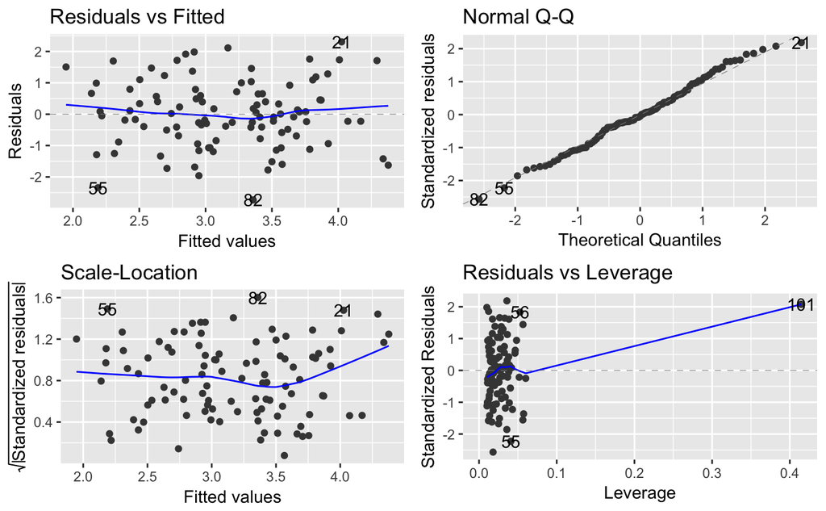

```r
autoplot(model_14gi)
```

En el modelo usando los dos predictores, el nuevo punto tiene alto apalancamiento, cosa visible en la gráfica cuatro arriba. Sin embargo, no es un *outlier*. Su residuo es de 1.707709; hay aún 7 puntos con mayor residuo y podemos ver en el siguiente diagrama que no sobresale de la distribución de los residuos

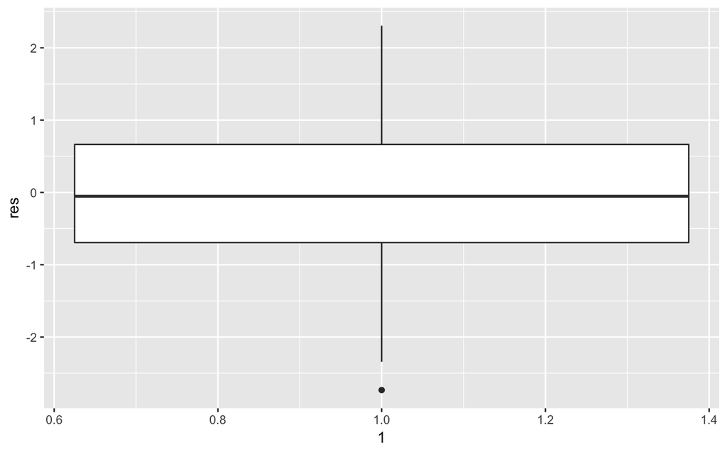

```r
data.frame(res = model_14gi$residuals) %>%
ggplot(aes(x = 1, y = res)) +
  geom_boxplot()
```

```r
model_14gii <- lm(y ~ x1)
summary(model_14gii)
```

```
Call:
lm(formula = y ~ x1)

Residuals:
    Min      1Q  Median      3Q     Max
-2.8897 -0.6556 -0.0909  0.5682  3.5665

Coefficients:
            Estimate Std. Error t value Pr(>|t|)
(Intercept)   2.2569     0.2390   9.445 1.78e-15 ***
x1            1.7657     0.4124   4.282 4.29e-05 ***
---
Signif. codes:  0 ‘***’ 0.001 ‘**’ 0.01 ‘*’ 0.05 ‘.’ 0.1 ‘ ’ 1

Residual standard error: 1.111 on 99 degrees of freedom
Multiple R-squared:  0.1562,    Adjusted R-squared:  0.1477
F-statistic: 18.33 on 1 and 99 DF,  p-value: 4.295e-05
```

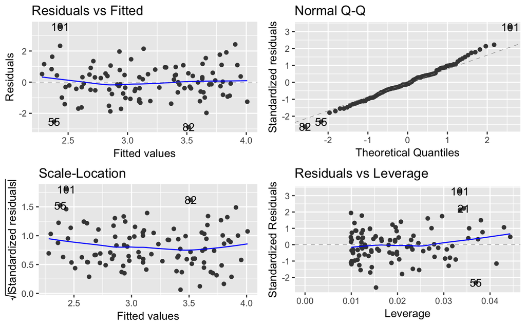

```r
autoplot(model_14gii)
```

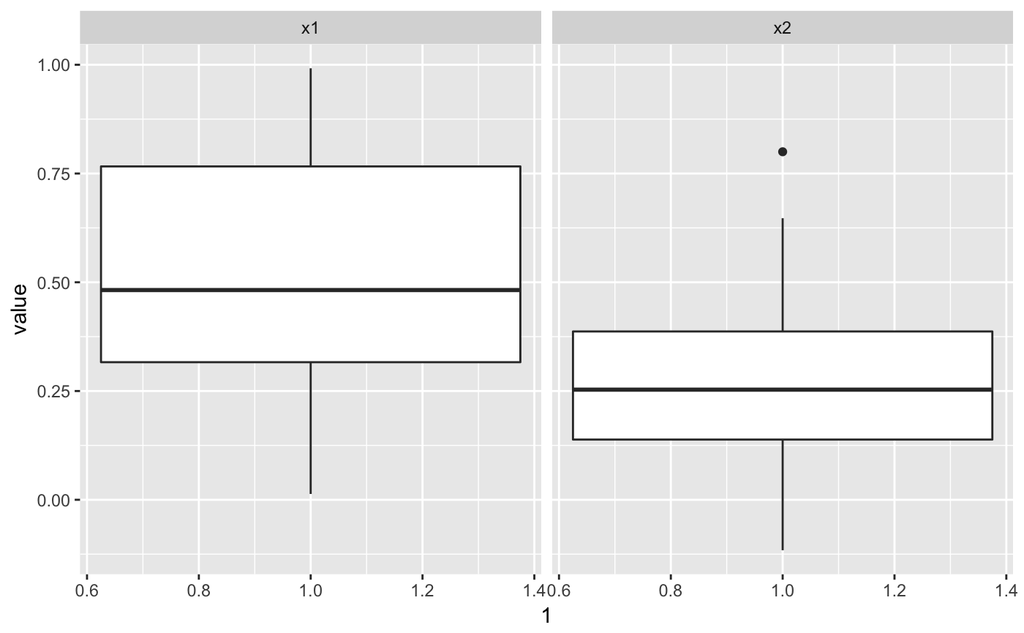

```r
data.frame(x1 = x1, x2 = x2) %>%
  gather(predictor, value) %>%
  ggplot(aes(x = 1, y = value)) +
  geom_boxplot() +
  facet_grid(. ~ predictor)
```

## Question 15

This problem involves the `Boston` data set, which we saw in the lab for this chapter. We will now try to predict per capita crime rate using the other variables in this data set. In other words, per capita crime rate is the response, and the other variables are the predictors.

**(a)** For each predictor, fit a simple linear regression model to predict the response. Describe your results. In which of the models is there a statistically significant association between the predictor and the response? Create some plots to back up your assertions.

```r
Boston %>%
  select(-crim) %>%
  names() %>%
  paste('crim ~ ', .) %>%
  map(as.formula) %>%
  map(lm, data = Boston) %>%
  map(summary)
```

```
[[1]]

Call:
.f(formula = .x[[i]], data = ..1)

Residuals:
   Min     1Q Median     3Q    Max
-4.429 -4.222 -2.620  1.250 84.523

Coefficients:
            Estimate Std. Error t value Pr(>|t|)
(Intercept)  4.45369    0.41722  10.675  < 2e-16 ***
zn          -0.07393    0.01609  -4.594 5.51e-06 ***
---
Signif. codes:  0 ‘***’ 0.001 ‘**’ 0.01 ‘*’ 0.05 ‘.’ 0.1 ‘ ’ 1

Residual standard error: 8.435 on 504 degrees of freedom
Multiple R-squared:  0.04019,   Adjusted R-squared:  0.03828
F-statistic:  21.1 on 1 and 504 DF,  p-value: 5.506e-06


[[2]]

Call:
.f(formula = .x[[i]], data = ..1)

Residuals:
    Min      1Q  Median      3Q     Max
-11.972  -2.698  -0.736   0.712  81.813

Coefficients:
            Estimate Std. Error t value Pr(>|t|)
(Intercept) -2.06374    0.66723  -3.093  0.00209 **
indus        0.50978    0.05102   9.991  < 2e-16 ***
---
Signif. codes:  0 ‘***’ 0.001 ‘**’ 0.01 ‘*’ 0.05 ‘.’ 0.1 ‘ ’ 1

Residual standard error: 7.866 on 504 degrees of freedom
Multiple R-squared:  0.1653,    Adjusted R-squared:  0.1637
F-statistic: 99.82 on 1 and 504 DF,  p-value: < 2.2e-16
```

[output cut: 216 more lines]

```

Residuals:
   Min     1Q Median     3Q    Max
-9.071 -4.022 -2.343  1.298 80.957

Coefficients:
            Estimate Std. Error t value Pr(>|t|)
(Intercept) 11.79654    0.93419   12.63   <2e-16 ***
medv        -0.36316    0.03839   -9.46   <2e-16 ***
---
Signif. codes:  0 ‘***’ 0.001 ‘**’ 0.01 ‘*’ 0.05 ‘.’ 0.1 ‘ ’ 1

Residual standard error: 7.934 on 504 degrees of freedom
Multiple R-squared:  0.1508,    Adjusted R-squared:  0.1491
F-statistic: 89.49 on 1 and 504 DF,  p-value: < 2.2e-16
```

En las variables `zn`, `indus`, `nox`, `rm`, `age`, `dis`, `rad`, `tax`, `ptratio`, `balck`, `lstat` y `medv` podemos rechazar la hipótesis nula.

**(b)** Fit a multiple regression model to predict the response using all of the predictors. Describe your results. For which predictors can we reject the null hypothesis $H_0 : \beta_j = 0$?

```r
summary(lm(crim ~ ., data = Boston))
```

```
Call:
lm(formula = crim ~ ., data = Boston)

Residuals:
   Min     1Q Median     3Q    Max
-9.924 -2.120 -0.353  1.019 75.051

Coefficients:
              Estimate Std. Error t value Pr(>|t|)
(Intercept)  17.033228   7.234903   2.354 0.018949 *
zn            0.044855   0.018734   2.394 0.017025 *
indus        -0.063855   0.083407  -0.766 0.444294
chas         -0.749134   1.180147  -0.635 0.525867
nox         -10.313535   5.275536  -1.955 0.051152 .
rm            0.430131   0.612830   0.702 0.483089
age           0.001452   0.017925   0.081 0.935488
dis          -0.987176   0.281817  -3.503 0.000502 ***
rad           0.588209   0.088049   6.680 6.46e-11 ***
tax          -0.003780   0.005156  -0.733 0.463793
ptratio      -0.271081   0.186450  -1.454 0.146611
black        -0.007538   0.003673  -2.052 0.040702 *
lstat         0.126211   0.075725   1.667 0.096208 .
medv         -0.198887   0.060516  -3.287 0.001087 **
---
Signif. codes:  0 ‘***’ 0.001 ‘**’ 0.01 ‘*’ 0.05 ‘.’ 0.1 ‘ ’ 1

Residual standard error: 6.439 on 492 degrees of freedom
Multiple R-squared:  0.454, Adjusted R-squared:  0.4396
F-statistic: 31.47 on 13 and 492 DF,  p-value: < 2.2e-16
```

En el modelo completo, solo con `dis` y `rad` podemos descartar la hipótesis nula por completo. `medv` tal vez.

**(c)** How do your results from (a) compare to your results from (b)? Create a plot displaying the univariate regression coefficients from (a) on the x-axis, and the multiple regression coefficients from (b) on the y-axis. That is, each predictor is displayed as a single point in the plot. Its coefficient in a simple linear regression model is shown on the x-axis, and its coefficient estimate in the multiple linear regression model is shown on the y-axis.

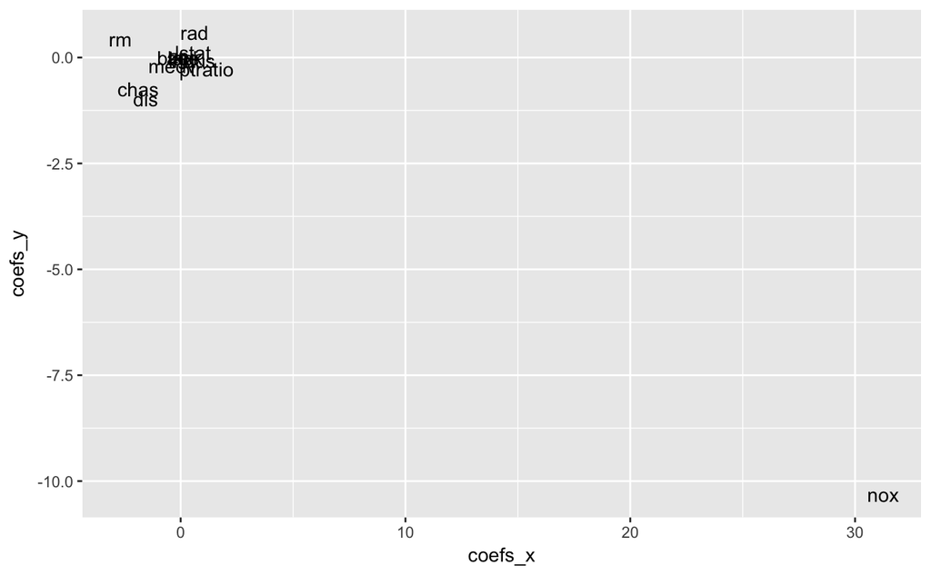

```r
predictor <- Boston%>%
  select(-crim) %>%
  names()
coefs_single <- predictor %>%
  paste('crim ~ ', .) %>%
  map(as.formula) %>%
  map(lm, data = Boston) %>%
  map(coef) %>%
  transpose()
names(coefs_single) <- c("intercepts", "predictors")
coefs_x <- unlist(coefs_single$predictors)
coefs_y <- model_q15b$coefficients[-1]
df <- data.frame(x = coefs_x, y = coefs_y, label = predictor)
ggplot(df, aes(x = coefs_x, y = coefs_y, label = label)) +
  geom_text()
```

El coeficiente de `nox` (concentración de óxido nitríco en partes por diez millones) es el que sufre un mayor cambio; pasa de más de 30 en el modelo individual a menos de -10 en el que tiene a todos.

**(d)** Is there evidence of non-linear association between any of the predictors and the response? To answer this question, for each predictor $X$, fit a model of the form
$$Y = \beta_0 + \beta_1X + \beta_2X^2 + \beta_3X^3 + \epsilon$$

```r
Boston %>%
  select(-c(chas, crim)) %>%
  names() %>%
  paste('crim ~ poly(',., ', 3)', sep = "") %>%
  map(as.formula) %>%
  map(lm, data = Boston) %>%
  map(summary)
```

```
[[1]]

Call:
.f(formula = .x[[i]], data = ..1)

Residuals:
   Min     1Q Median     3Q    Max
-4.821 -4.614 -1.294  0.473 84.130

Coefficients:
             Estimate Std. Error t value Pr(>|t|)
(Intercept)    3.6135     0.3722   9.709  < 2e-16 ***
poly(zn, 3)1 -38.7498     8.3722  -4.628  4.7e-06 ***
poly(zn, 3)2  23.9398     8.3722   2.859  0.00442 **
poly(zn, 3)3 -10.0719     8.3722  -1.203  0.22954
---
Signif. codes:  0 ‘***’ 0.001 ‘**’ 0.01 ‘*’ 0.05 ‘.’ 0.1 ‘ ’ 1

Residual standard error: 8.372 on 502 degrees of freedom
Multiple R-squared:  0.05824,   Adjusted R-squared:  0.05261
F-statistic: 10.35 on 3 and 502 DF,  p-value: 1.281e-06


[[2]]

Call:
.f(formula = .x[[i]], data = ..1)

Residuals:
   Min     1Q Median     3Q    Max
-8.278 -2.514  0.054  0.764 79.713

Coefficients:
                Estimate Std. Error t value Pr(>|t|)
(Intercept)        3.614      0.330  10.950  < 2e-16 ***
poly(indus, 3)1   78.591      7.423  10.587  < 2e-16 ***
poly(indus, 3)2  -24.395      7.423  -3.286  0.00109 **
poly(indus, 3)3  -54.130      7.423  -7.292  1.2e-12 ***
---
Signif. codes:  0 ‘***’ 0.001 ‘**’ 0.01 ‘*’ 0.05 ‘.’ 0.1 ‘ ’ 1
```

[output cut: 219 more lines]

```
    Min      1Q  Median      3Q     Max
-24.427  -1.976  -0.437   0.439  73.655

Coefficients:
               Estimate Std. Error t value Pr(>|t|)
(Intercept)       3.614      0.292  12.374  < 2e-16 ***
poly(medv, 3)1  -75.058      6.569 -11.426  < 2e-16 ***
poly(medv, 3)2   88.086      6.569  13.409  < 2e-16 ***
poly(medv, 3)3  -48.033      6.569  -7.312 1.05e-12 ***
---
Signif. codes:  0 ‘***’ 0.001 ‘**’ 0.01 ‘*’ 0.05 ‘.’ 0.1 ‘ ’ 1

Residual standard error: 6.569 on 502 degrees of freedom
Multiple R-squared:  0.4202,    Adjusted R-squared:  0.4167
F-statistic: 121.3 on 3 and 502 DF,  p-value: < 2.2e-16
```

Las variables `indus`, `nox`, `dis` y `medv` presentan evidencia de no-linealidad hasta grado tres, mientras que `rm`, `age` y `tax` lo hacen hasta grado dos.